# COMPSCIX 415.2 Homework 7

Shan Valleru

3/17/2019

My Github repository for my assignments can be found at this URL: https://github.com/svalleru/compscix-415-2-assignments

```r
library(tidyverse)
library(broom)
```

# Exercise 1

1.Load the train.csv dataset into R. How many observations and columns are there?

```r
file_path <- '/Users/svalleru/Desktop/UCB/COMPSCIX415.2-003 - Intro to DS/compscix-415-2-assignments/session7/train.csv'
training_data <- read_csv(file = file_path)
glimpse(training_data)
```

```
## Observations: 1,460
## Variables: 81
## $ Id            <dbl> 1, 2, 3, 4, 5, 6, 7, 8, 9, 10, 11, 12, 13, 14, 15,…
## $ MSSubClass    <dbl> 60, 20, 60, 70, 60, 50, 20, 60, 50, 190, 20, 60, 2…
## $ MSZoning      <chr> "RL", "RL", "RL", "RL", "RL", "RL", "RL", "RL", "R…
## $ LotFrontage   <dbl> 65, 80, 68, 60, 84, 85, 75, NA, 51, 50, 70, 85, NA…
## $ LotArea       <dbl> 8450, 9600, 11250, 9550, 14260, 14115, 10084, 1038…
## $ Street        <chr> "Pave", "Pave", "Pave", "Pave", "Pave", "Pave", "P…
## $ Alley         <chr> NA, NA, NA, NA, NA, NA, NA, NA, NA, NA, NA, NA, NA…
## $ LotShape      <chr> "Reg", "Reg", "IR1", "IR1", "IR1", "IR1", "Reg", "…
## $ LandContour   <chr> "Lvl", "Lvl", "Lvl", "Lvl", "Lvl", "Lvl", "Lvl", "…
## $ Utilities     <chr> "AllPub", "AllPub", "AllPub", "AllPub", "AllPub", …
## $ LotConfig     <chr> "Inside", "FR2", "Inside", "Corner", "FR2", "Insid…
## $ LandSlope     <chr> "Gtl", "Gtl", "Gtl", "Gtl", "Gtl", "Gtl", "Gtl", "…
## $ Neighborhood  <chr> "CollgCr", "Veenker", "CollgCr", "Crawfor", "NoRid…
```

[output cut: 68 more lines]

# Exercise 2

1.Normally at this point you would spend a few days on EDA, but for this homework we will do some very basic EDA and get right to fitting some linear regression models.

Our target will be `SalePrice`.

- Visualize the distribution of `SalePrice`.

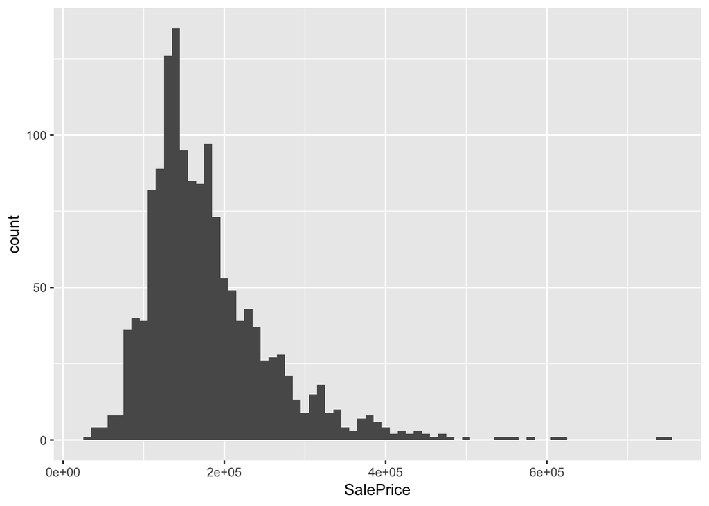

```r
ggplot(data = training_data, mapping = aes(x = SalePrice)) +
  geom_histogram(binwidth = 10000)
```

- Visualize the covariation between `SalePrice` and `Neighborhood`.

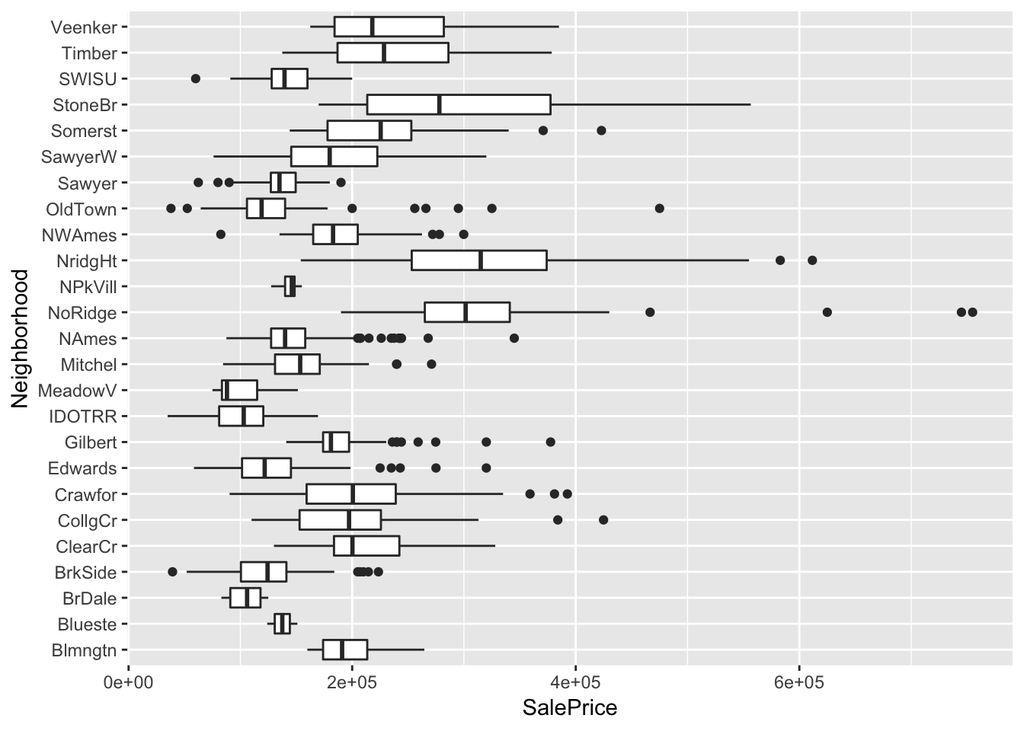

```r
ggplot(data = training_data, mapping = aes(x = Neighborhood, y = SalePrice)) +
  geom_boxplot() +
  coord_flip()
```

- Visualize the covariation between `SalePrice` and `OverallQual`.

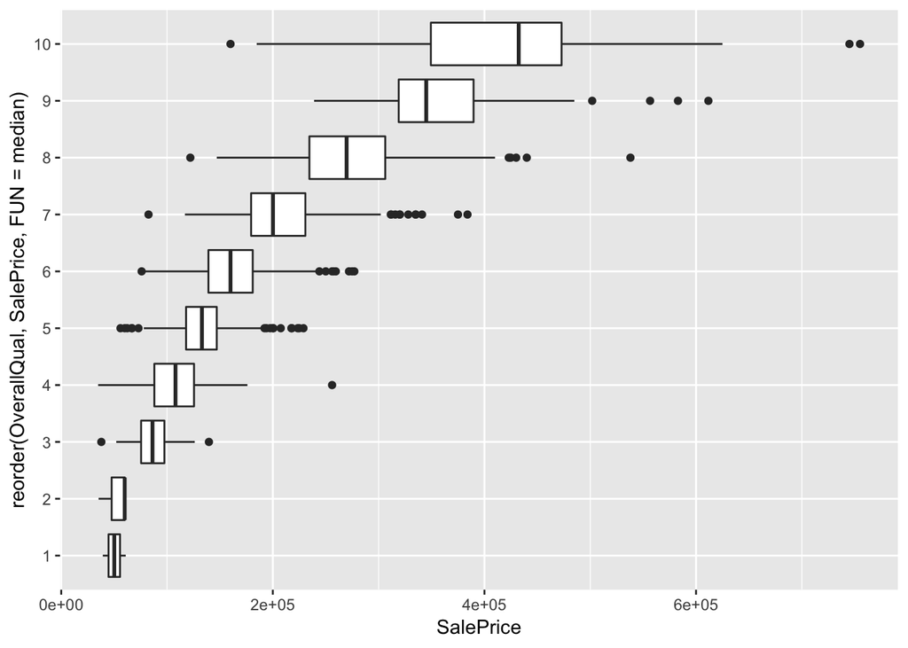

```r
ggplot(data = training_data) +
  geom_boxplot(mapping = aes(x = reorder(OverallQual, SalePrice, FUN = median), y = SalePrice)) +
  coord_flip()
```

# Exercise 3

1.Our target is called `SalePrice`. First, we can fit a simple regression model consisting of only the intercept (the average of `SalePrice`). Fit the model and then use the broom package to

- take a look at the coefficient,
- compare the coefficient to the average value of `SalePrice`, and
- take a look at the R-squared.

```r
(sale_price_lm <- lm(formula = SalePrice ~ 1, data = training_data))
```

```
##
## Call:
## lm(formula = SalePrice ~ 1, data = training_data)
##
## Coefficients:
## (Intercept)
##      180921
```

```r
# tidy(house_lm)
mean(training_data$SalePrice, na.rm = TRUE)
```

```
## [1] 180921.2
```

```r
glance(sale_price_lm)
```

```
## # A tibble: 1 x 11
##   r.squared adj.r.squared  sigma statistic p.value    df  logLik    AIC
##       <dbl>         <dbl>  <dbl>     <dbl>   <dbl> <int>   <dbl>  <dbl>
## 1         0             0 79443.        NA      NA     1 -18544. 37092.
## # … with 3 more variables: BIC <dbl>, deviance <dbl>, df.residual <int>
```

# Exercise 4

Exercise 4 1.Now fit a linear regression model using `GrLivArea`, `OverallQual`, and `Neighborhood` as the features. Don’t forget to look at `data_description.txt` to understand what these variables mean. Ask **yourself** these questions before fitting the model:

What kind of relationship will these features have with our target? Can the relationship be estimated linearly? Are these good features, given the problem we are trying to solve? After fitting the model, output the coefficients and the R-squared using the broom package.

```r
sale_price_lm <- lm(formula = SalePrice ~ GrLivArea + OverallQual + Neighborhood, data = training_data)
tidy(sale_price_lm)
```

```
## # A tibble: 27 x 5
##    term                estimate std.error statistic  p.value
##    <chr>                  <dbl>     <dbl>     <dbl>    <dbl>
##  1 (Intercept)         -34829.   11541.       -3.02 2.59e- 3
##  2 GrLivArea               55.6      2.50     22.2  2.38e-94
##  3 OverallQual          20951.    1162.       18.0  1.24e-65
##  4 NeighborhoodBlueste -30753.   27697.       -1.11 2.67e- 1
##  5 NeighborhoodBrDale  -43359.   12979.       -3.34 8.57e- 4
##  6 NeighborhoodBrkSide -13025.   10450.       -1.25 2.13e- 1
##  7 NeighborhoodClearCr  24576.   11570.        2.12 3.38e- 2
##  8 NeighborhoodCollgCr  11414.    9497.        1.20 2.30e- 1
##  9 NeighborhoodCrawfor  14444.   10502.        1.38 1.69e- 1
## 10 NeighborhoodEdwards -17843.    9986.       -1.79 7.42e- 2
## # … with 17 more rows
```

```r
glance(sale_price_lm)
```

```
## # A tibble: 1 x 11
##   r.squared adj.r.squared  sigma statistic p.value    df  logLik    AIC
##       <dbl>         <dbl>  <dbl>     <dbl>   <dbl> <int>   <dbl>  <dbl>
## 1     0.787         0.783 37009.      203.       0    27 -17416. 34887.
## # … with 3 more variables: BIC <dbl>, deviance <dbl>, df.residual <int>
```

Answer these questions:

- How would you interpret the coefficients on `GrLivArea` and `OverallQual`?

When all other features are constant, increase in one square feet area in `GrLivArea` increases `SalePrice` $55. When all other features are constant, increase in 1 unit of `OverallQual` increases `SalePrice` by $20951.

- How would you interpret the coefficient on `NeighborhoodBrkSide`?

When all other features are constant, `SalePrice` in `NeighborhoodBrkSide` are on average $13025 lower relative to those in `NeighborhoodBlmngtn`.

- Are the features significant?

- Are the features practically significant?

Yes

- Is the model a good fit?

# Exercise 6

1.One downside of the linear model is that it is sensitive to unusual values because the distance incorporates a squared term. Fit a linear model to the simulated data below (use `y` as the target and `x` as the feature), and look at the resulting coefficients and R-squared. Rerun it about 5-6 times to generate different simulated datasets. What do you notice about the model’s coefficient on `x` and the R-squared values?

```r
sim1a <- tibble(
  x = rep(1:10, each = 3),
  y = x * 1.5 + 6 + rt(length(x), df = 2)
)

sim_lm <- lm(formula =  y ~ x, data = sim1a)
tidy(sim_lm)
```

```
## # A tibble: 2 x 5
##   term        estimate std.error statistic  p.value
##   <chr>          <dbl>     <dbl>     <dbl>    <dbl>
## 1 (Intercept)     6.46     0.623      10.4 4.28e-11
## 2 x               1.42     0.100      14.2 2.65e-14
```

```r
glance(sim_lm)
```

```
## # A tibble: 1 x 11
##   r.squared adj.r.squared sigma statistic  p.value    df logLik   AIC   BIC
##       <dbl>         <dbl> <dbl>     <dbl>    <dbl> <int>  <dbl> <dbl> <dbl>
## 1     0.878         0.873  1.58      201. 2.65e-14     2  -55.2  116.  121.
## # … with 2 more variables: deviance <dbl>, df.residual <int>
```

```r
intercepts <- c()
coefficients <- c()
rsquared <- c()
adj_rsquared <- c()

for(i in 1:6){
  sim1a <- tibble(
  x = rep(1:10, each = 3),
  y = x * 1.5 + 6 + rt(length(x), df = 2)
  )
  sim_lm <- lm(formula =  y ~ x, data = sim1a)
  tidy_obj <- tidy(sim_lm)
  glance_obj <- glance(sim_lm)
  intercepts[i] <- tidy_obj$estimate[1]
  coefficients[i] <- tidy_obj$estimate[2]
  rsquared[i] <- glance_obj$r.squared
  adj_rsquared[i] <- glance_obj$adj.r.squared
}
coefficients
```

```
## [1] 1.241455 1.622874 1.507233 1.692388 1.657289 2.049374
```

```r
rsquared
```

```
## [1] 0.6181042 0.4077130 0.8787374 0.8855047 0.7330188 0.9088289
```

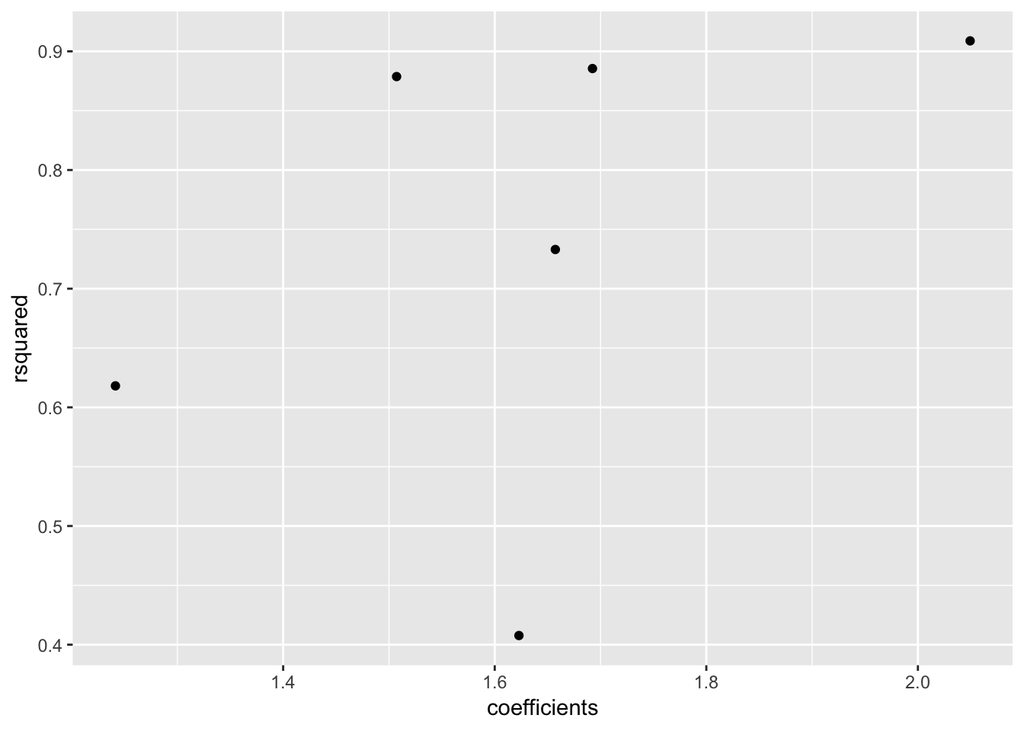

```r
ggplot(mapping = aes(x = coefficients, y = rsquared)) +
  geom_point()
```

Both coefficient and R-squared values are fluctuating across multiple runs. R-squared more so than coefficient.